# Задание 1. Рассчет основных показателей

Дмитрий Бодунов

29 октября 2016 г

Задача - рассчитать основные показатели:

- Средний чек магазина,
- Среднее количествово чеков на 1 магазин в день,
- Средние продажи на 1 магазин в день,  
  И сравнить показатели в октябре и ноябре между магазинами

#### **Средний чек магазина:**

Средний чек магазина рассчитывается как сумма по полю SALES, деленная на количество чеков (TXN).

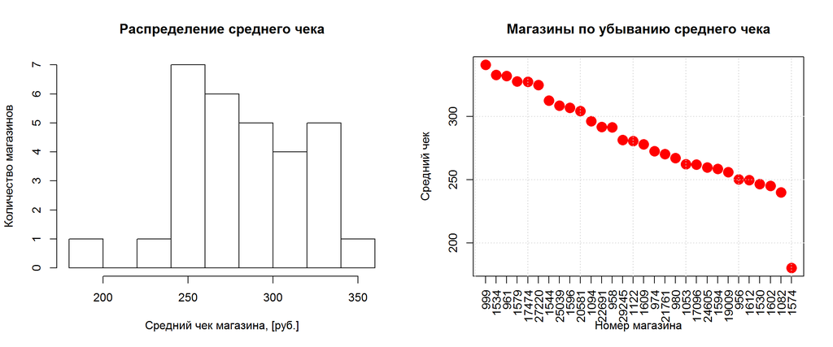

Из графиков видно что магазин **1574** выбивается из общей картины. Причины такого отклонения необходимо исследовать отдельно.

#### **Среднее количество чеков на 1 магазин:**

[interactive chart not shown]

#### **Средние продажи на 1 магазин:**

[interactive chart not shown]

#### **Средний чек:**

[interactive chart not shown]

У каждого из приведенных показателей имеется ярко выраженная сезонность в рамках недели. При этом сезонность каждого параметра сильно отличается от сезонности любого другого.

### **Сравние показателей:**

Для сравнения показателей будем сравнивать текущее значение и значение 28 дней назад. Сравнивать значения 1 октября и 1 ноября некорректно, т.к. эти даты приходятся на разные дни недели и за счет недельной сезонности не будут отражать реальное изменение покупательского поведения.

#### **Изменение количества чеков:**

[interactive chart not shown]

Из приведенного выше графика видно, что *количество чеков* в среднем *растет* по сравнению к предыдущему месяцу.

#### **Изменение средних продаж магазинов:**

[interactive chart not shown]

Видно, что *продажи*, в среднем, *держатся на одном уровне*. Явные тренды на рост и снижение продаж отсутствуют.

#### **Изменение среднего чека:**

[interactive chart not shown]

Из графика видно, что *средний чек падает*, причины падения необходимо выяснять отдельно.

### **Изменение показателей по каждому магазину:**

Ниже приведено изменение показателей для каждого магазина на конкретную дату.

#### **Изменение количества чеков, [%]:**

[interactive chart not shown]

#### **Изменение продаж, [%]:**

[interactive chart not shown]

#### **Изменение среднего чека, [%]:**

[interactive chart not shown]

Явных *закономерностей* на приведенных графиках *не обнаружено*. При необходимости все полученные данные можно экспортировать в MS Excel.